# Aggregator analysis

Online sales report

17/10/2020

**Performance report**

| name | Avg | Percentage |
| --- | --- | --- |
| Avg number of errors | 10500 | 37.92942 |
| Avg number of late but success | 11547 | 41.71152 |
| Avg number of success | 5636 | 20.35907 |
| Total number of requests | 27683 | 100.00000 |

| Average responses measured in 3 month period | count | Ratio |
| --- | --- | --- |
| number of requests | 27670 | 100% |
| avg number of success | 5651 | 20% |
| avg number of late but success (late_success) | 11545 | 42% |
| avg number of errors | 10473 | 38% |

Below are top 5 errors showed in percentatge of total errors

[output not shown]

**The first observation**

We will view the behavior of late but success and error reponses with the number of requests using the a linear model method

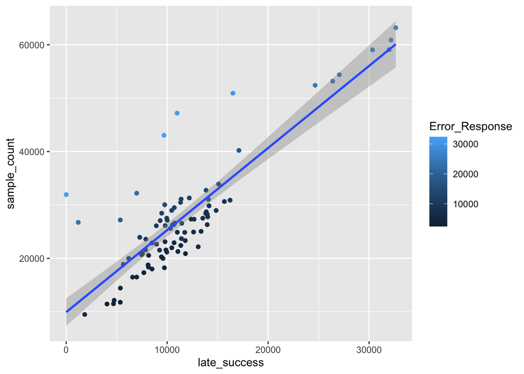

if you notice there is a relation in the model between variables , we will dive deeper and identify which variable is more likely to have relation with the total number of requests this to prove that the late responses are not related to connectivity but instead it is related to system processing

**What about the late but success responses**

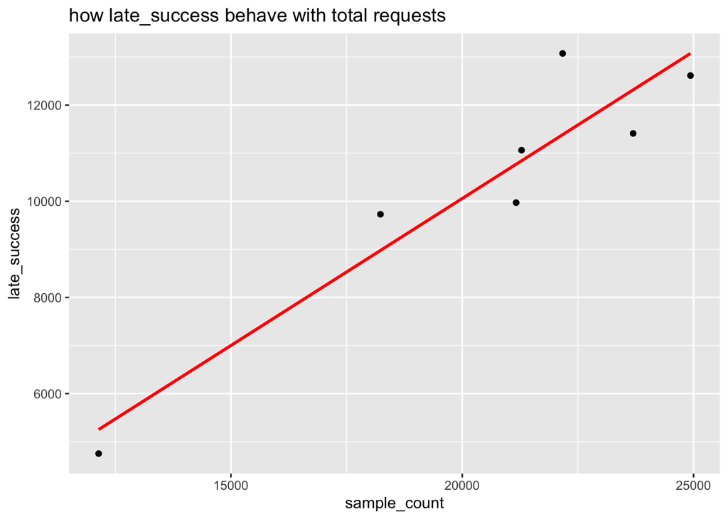

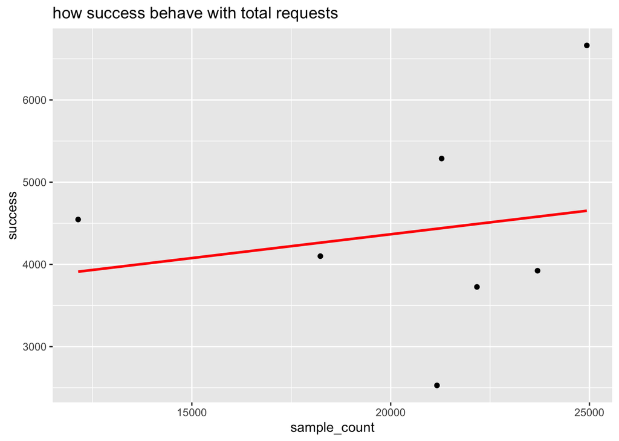

- There is an evidence that the number of requests increase when the number of late responses increase , which means that the late responses are not related to **connectivity factor** and that we have a problem in processing the information.
- There is an association between late but success and number of requests.
- We can use the number of requests to predict the late but success responses and vice versa.

…